## Buntes Treiben

Die Funktion `persp()` aus dem Basispaket `graphics` zeichnet 3D-Plots. Das `animation`-Paket kann animierte Bilder in vielen Formaten erzeugen.

1. Lesen sie die Hilfe zu `persp` und führen Sie die Beispiele aus.
2. Schreiben Sie eine Funktion

```r
colorpersp <- function(x, y, z, z_palette) {
#TODO
}
```

die Beispiel 4 (“Surface colours corresponding to z-values”) aus der Hilfe von `persp()` direkt implementiert. `z_palette` ist dabei ein Vektor von Farben in der die Facetten der geplotteten Oberfläche je nach $z$-Wert eingefärbt werden sollen. Ihre Funktion sollte folgende Grafik reproduzieren können:

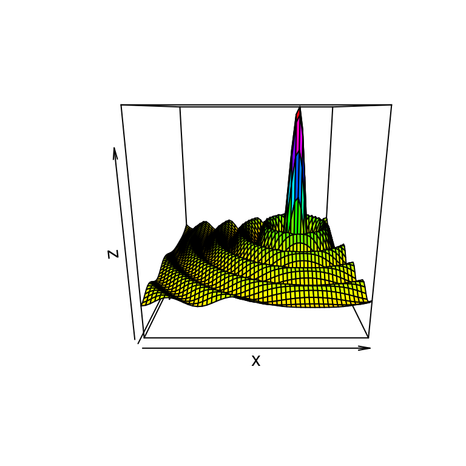

```r
n_grid <- 50
x <- seq(-30, 10, length = n_grid)
y <- x
drip_drop <- function(x, y, time = pi / 2) {
  r <- sqrt(x^2 + y^2)
  sin(time) * sin(r) / r
}
z <- outer(x, y, drip_drop)
colors <- rainbow(100)
colorpersp(x = x, y = y, z = z, z_palette = colors)
```

3. Modifizieren Sie Ihre `colorpersp`-Funktion so, dass sie
- zusätzlich die Argumente `zlim`, `box`, `border`, `theta` und `phi` annimmt und an `persp` übergibt
- die Farbwerte der Palette über die Spannweite von `zlim` verteilt, nicht über die Spannweite der Daten in `z`.

Plotten Sie `drip_drop()` ohne die Gitterlinien und ohne Koordinatensystem mit Blick von schräg oben, einmal auf $[-30, 10] \times [-30, 10]$ wie oben, und einmal auf $[-5, 10] \times [-5, 10]$. Das sollte dann in etwa so aussehen:

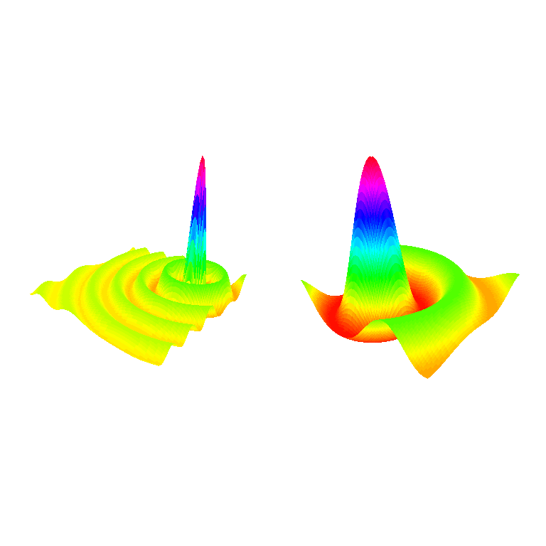

4. Schreiben Sie eine Funktion `bounce_bounce(<argumente>)` mit der sie so etwas wie die Animation [hier (gif)](http://scheipl.userweb.mwn.de/downloads/fortprog/bounce-bounce.gif) reproduzieren können.  
   Gezeigt wird hier der Bildausschnitt für $[-10, 20] \times [-10, 20] \times [-1, 1]$, die Palette ist `rainbow(100)`. Die Perspektive ist `theta = 40, phi = 15`, die Beleuchtung ist `lphi = 90, shade = 0.7`.